# PISA

Andrea Jiménez Zúñiga

11/9/2020

```r
library(ISLR)
library(boot)
library(splines)
library(ggplot2)
library(gam)
library(readr)
library(tidyverse)
library(broom)
library(flextable)
library(reshape2)
library(imputeTS)
library(skimr)
library(magrittr)
library(janitor)
```

# Read Data

```r
pisa <- read_csv("~/Desktop/CUNEF/PREDICCIÓN/PRACTICAS/PISA/pisasci2006.csv")
View(pisa)
attach(pisa)
```

```r
pisa %<>% clean_names()
colnames(pisa)
```

```
##  [1] "country"  "overall"  "issues"   "explain"  "evidence" "interest"
##  [7] "support"  "income"   "health"   "edu"      "hdi"
```

# Summarize Data

```r
skim(pisa)
```

Data summary

| Name | pisa |
| --- | --- |
| Number of rows | 65 |
| Number of columns | 11 |
| _______________________ |  |
| Column type frequency: |  |
| character | 1 |
| numeric | 10 |
| ________________________ |  |
| Group variables | None |

**Variable type: character**

| skim_variable | n_missing | complete_rate | min | max | empty | n_unique | whitespace |
| --- | --- | --- | --- | --- | --- | --- | --- |
| country | 0 | 1 | 4 | 24 | 0 | 65 | 0 |

**Variable type: numeric**

| skim_variable | n_missing | complete_rate | mean | sd | p0 | p25 | p50 | p75 | p100 | hist |
| --- | --- | --- | --- | --- | --- | --- | --- | --- | --- | --- |
| overall | 8 | 0.88 | 473.14 | 54.58 | 322.00 | 428.00 | 489.00 | 513.00 | 563.00 | ▁▃▂▇▅ |
| issues | 8 | 0.88 | 469.91 | 53.93 | 321.00 | 427.00 | 489.00 | 514.00 | 555.00 | ▁▃▂▇▆ |
| explain | 8 | 0.88 | 475.02 | 54.02 | 334.00 | 432.00 | 490.00 | 517.00 | 566.00 | ▁▃▂▇▃ |
| evidence | 8 | 0.88 | 469.81 | 61.74 | 288.00 | 423.00 | 489.00 | 515.00 | 567.00 | ▁▂▃▇▆ |
| interest | 8 | 0.88 | 528.16 | 49.84 | 448.00 | 501.00 | 522.00 | 565.00 | 644.00 | ▆▇▅▃▂ |
| support | 8 | 0.88 | 512.18 | 26.08 | 447.00 | 494.00 | 512.00 | 529.00 | 569.00 | ▂▅▇▆▂ |
| income | 4 | 0.94 | 0.74 | 0.11 | 0.41 | 0.66 | 0.76 | 0.83 | 0.94 | ▁▃▇▇▆ |
| health | 4 | 0.94 | 0.89 | 0.07 | 0.72 | 0.84 | 0.89 | 0.94 | 0.99 | ▂▂▇▆▇ |
| edu | 6 | 0.91 | 0.80 | 0.11 | 0.54 | 0.72 | 0.81 | 0.88 | 0.99 | ▂▅▆▇▅ |
| hdi | 6 | 0.91 | 0.81 | 0.09 | 0.58 | 0.75 | 0.82 | 0.88 | 0.94 | ▁▃▇▇▇ |

Se puede observar que hay datos que faltan, por lo que en lugar de eliminarlos voy a hacer la media de los mismos para no perder muchas observaciones, ya que nuestra base de datos no es grande.

```r
pisa %<>% na_mean()

skim(pisa)
```

Data summary

| Name | pisa |
| --- | --- |
| Number of rows | 65 |
| Number of columns | 11 |
| _______________________ |  |
| Column type frequency: |  |
| character | 1 |
| numeric | 10 |
| ________________________ |  |
| Group variables | None |

**Variable type: character**

| skim_variable | n_missing | complete_rate | min | max | empty | n_unique | whitespace |
| --- | --- | --- | --- | --- | --- | --- | --- |
| country | 0 | 1 | 4 | 24 | 0 | 65 | 0 |

**Variable type: numeric**

| skim_variable | n_missing | complete_rate | mean | sd | p0 | p25 | p50 | p75 | p100 | hist |
| --- | --- | --- | --- | --- | --- | --- | --- | --- | --- | --- |
| overall | 0 | 1 | 473.14 | 51.06 | 322.00 | 436.00 | 487.00 | 511.00 | 563.00 | ▁▂▂▇▃ |
| issues | 0 | 1 | 469.91 | 50.44 | 321.00 | 431.00 | 483.00 | 509.00 | 555.00 | ▁▂▂▇▅ |
| explain | 0 | 1 | 475.02 | 50.53 | 334.00 | 441.00 | 483.00 | 516.00 | 566.00 | ▁▂▂▇▃ |
| evidence | 0 | 1 | 469.81 | 57.75 | 288.00 | 429.00 | 481.00 | 512.00 | 567.00 | ▁▂▂▇▅ |
| interest | 0 | 1 | 528.16 | 46.62 | 448.00 | 503.00 | 528.16 | 549.00 | 644.00 | ▆▇▇▃▂ |
| support | 0 | 1 | 512.18 | 24.40 | 447.00 | 497.00 | 512.18 | 527.00 | 569.00 | ▂▃▇▅▂ |
| income | 0 | 1 | 0.74 | 0.11 | 0.41 | 0.66 | 0.74 | 0.83 | 0.94 | ▁▂▆▇▅ |
| health | 0 | 1 | 0.89 | 0.06 | 0.72 | 0.84 | 0.89 | 0.94 | 0.99 | ▂▂▇▇▇ |
| edu | 0 | 1 | 0.80 | 0.11 | 0.54 | 0.74 | 0.80 | 0.87 | 0.99 | ▂▃▇▇▅ |
| hdi | 0 | 1 | 0.81 | 0.08 | 0.58 | 0.75 | 0.81 | 0.87 | 0.94 | ▁▃▆▇▆ |

# Smooth Splines

Voy a calcular los splines a través de smooth splines, sacando los grados de libertad de cada una con la ventaja de que el valor óptimo de smoothness se puede identificar por cross validation.

```r
attach(pisa)

intLims <- range(interest)

plot(interest, overall, xlim=intLims, col='gray')
title('Smoothing Spline')
fit <- smooth.spline(interest, overall, df=7)
fit2 <- smooth.spline(interest, overall, cv=TRUE)
fit2$df
```

```
## [1] 4.750171
```

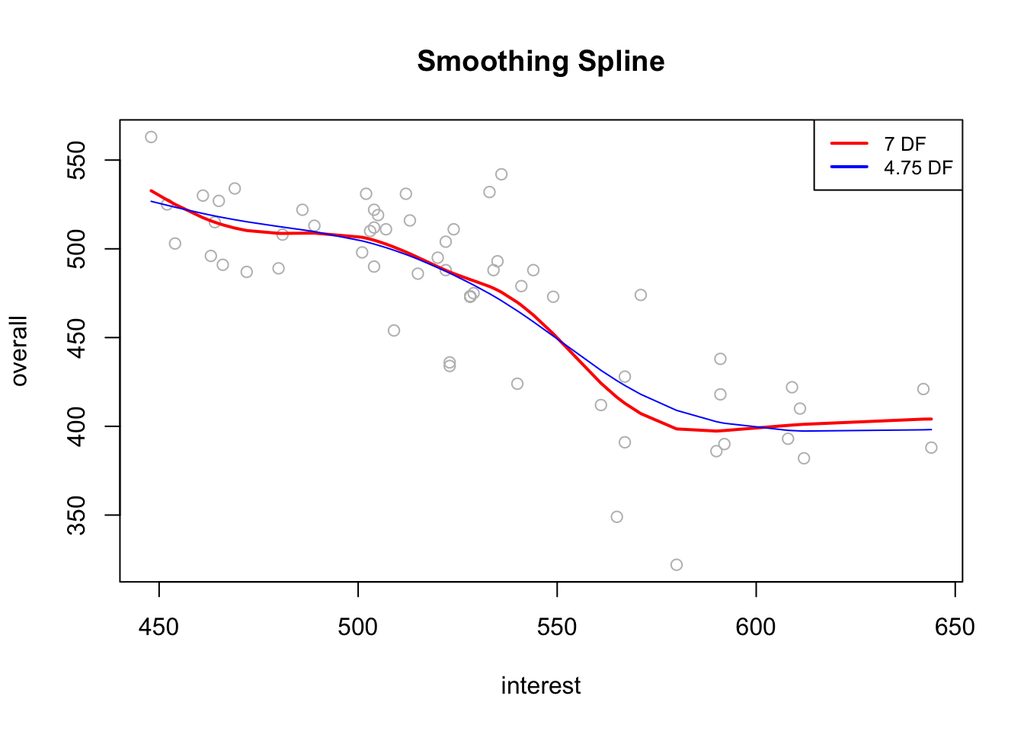

```r
lines(fit, col='red', lwd=2)
lines(fit2, col='blue', lwd=1)
legend('topright', legend=c('7 DF', '4.75 DF'),
       col=c('red','blue'), lty=1, lwd=2, cex=0.8)
```

```r
supLims <- range(support)

plot(support, overall, xlim=supLims, col='gray')
title('Smoothing Spline')
fit <- smooth.spline(support, overall, df=7)
fit2 <- smooth.spline(support, overall, cv=TRUE)
fit2$df
```

```
## [1] 2.001243
```

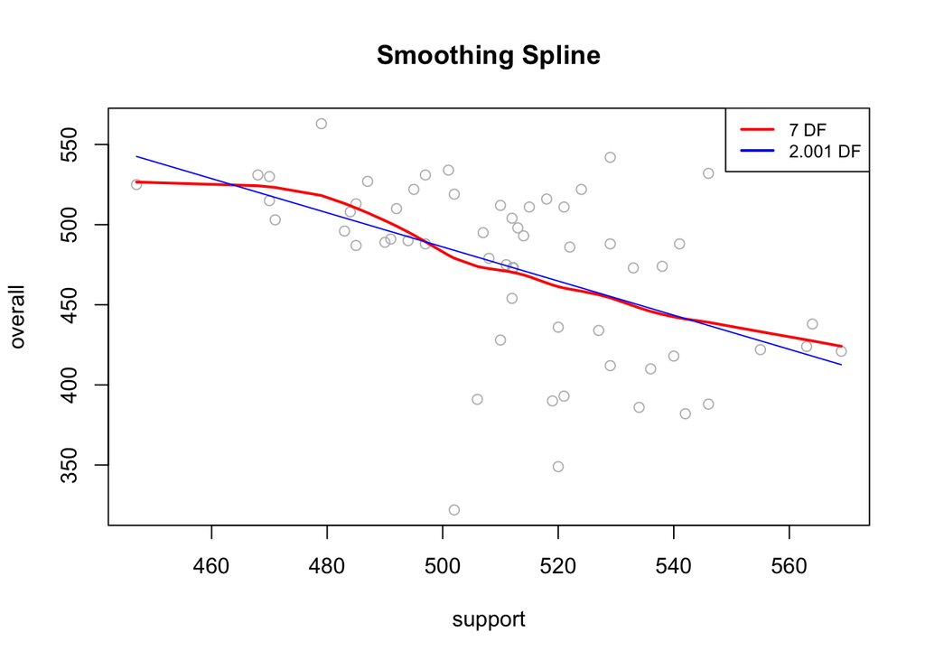

```r
lines(fit, col='red', lwd=2)
lines(fit2, col='blue', lwd=1)
legend('topright', legend=c('7 DF', '2.001 DF'),
       col=c('red','blue'), lty=1, lwd=2, cex=0.8)
```

```r
inLims <- range(income)

plot(income, overall, xlim=inLims, col='gray')
title('Smoothing Spline')
fit <- smooth.spline(income, overall, df=8)
fit2 <- smooth.spline(income, overall, cv=TRUE)
fit2$df
```

```
## [1] 4.244952
```

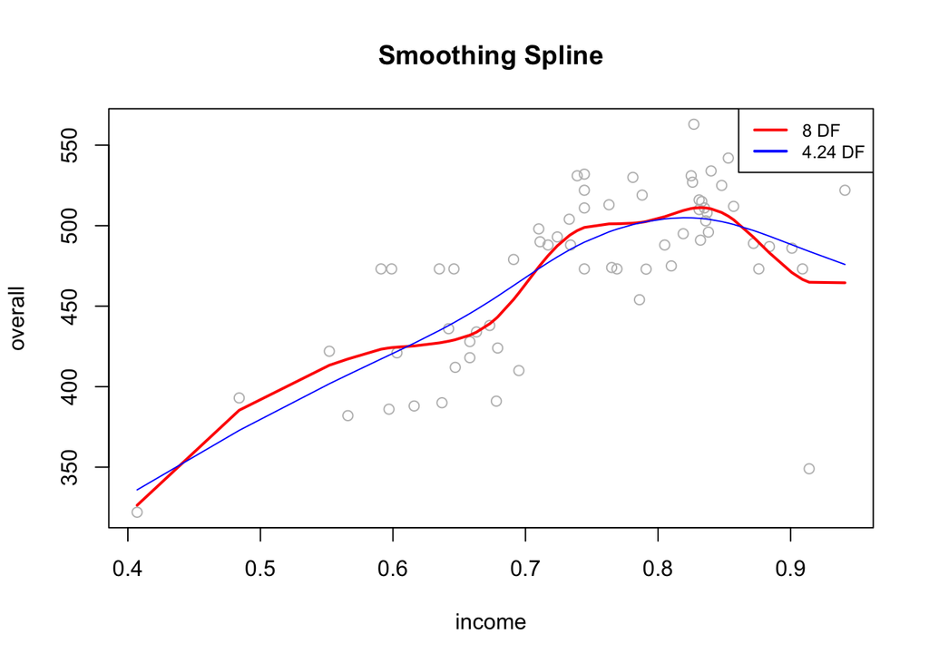

```r
lines(fit, col='red', lwd=2)
lines(fit2, col='blue', lwd=1)
legend('topright', legend=c('8 DF', '4.24 DF'),
       col=c('red','blue'), lty=1, lwd=2, cex=0.8)
```

```r
heLims <- range(health)

plot(health, overall, xlim=heLims, col='gray')
title('Smoothing Spline')
fit <- smooth.spline(health, overall, df=4)
fit2 <- smooth.spline(health, overall, cv=TRUE)
fit2$df
```

```
## [1] 2.002844
```

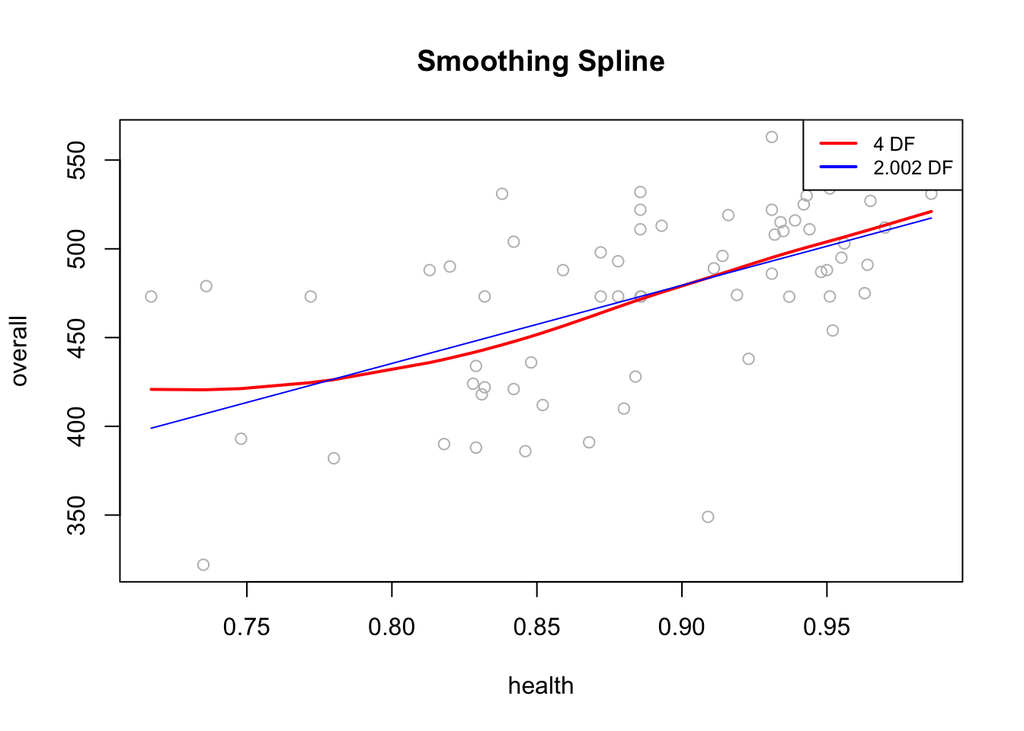

```r
lines(fit, col='red', lwd=2)
lines(fit2, col='blue', lwd=1)
legend('topright', legend=c('4 DF', '2.002 DF'),
       col=c('red','blue'), lty=1, lwd=2, cex=0.8)
```

```r
eduLims <- range(edu)

plot(edu, overall, xlim=eduLims, col='gray')
title('Smoothing Spline')
fit <- smooth.spline(edu, overall, df=6)
fit2 <- smooth.spline(edu, overall, cv=TRUE)
fit2$df
```

```
## [1] 2.002385
```

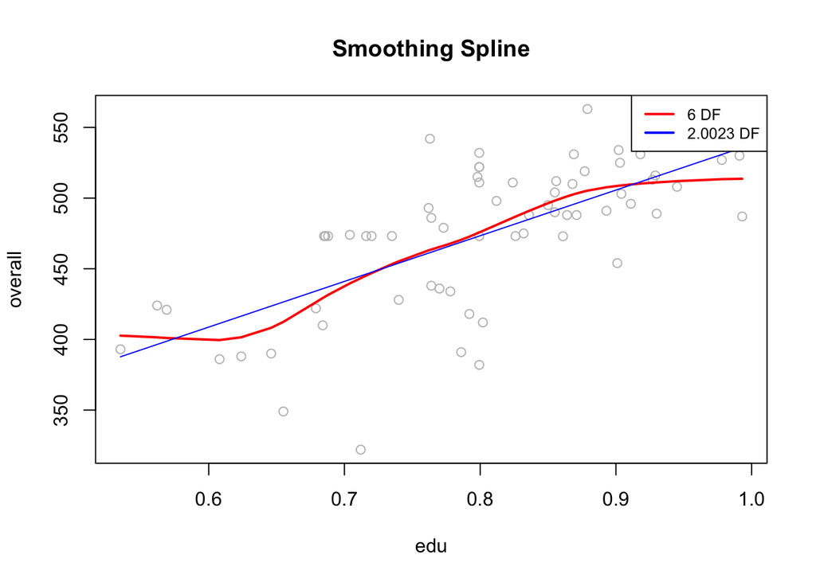

```r
lines(fit, col='red', lwd=2)
lines(fit2, col='blue', lwd=1)
legend('topright', legend=c('6 DF', '2.0023 DF'),
       col=c('red','blue'), lty=1, lwd=2, cex=0.8)
```

```r
hdiLims <- range(hdi)

plot(hdi, overall, xlim=hdiLims, col='gray')
title('Smoothing Spline')
fit <- smooth.spline(hdi, overall, df=10)
fit2 <- smooth.spline(hdi, overall, cv=TRUE)
fit2$df
```

```
## [1] 8.603228
```

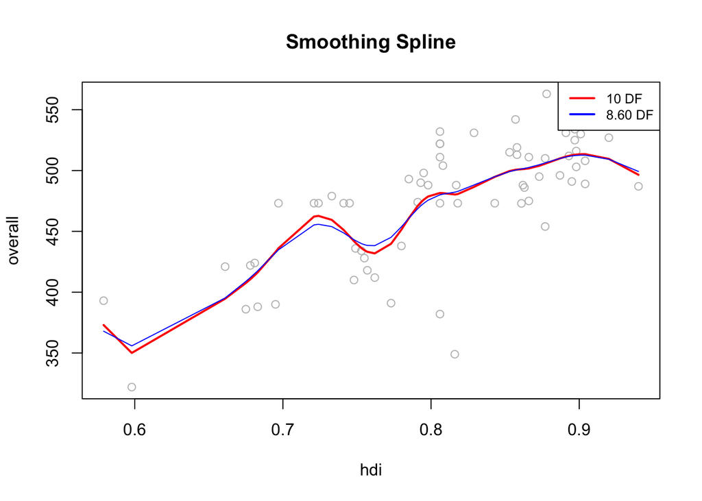

```r
lines(fit, col='red', lwd=2)
lines(fit2, col='blue', lwd=1)
legend('topright', legend=c('10 DF', '8.60 DF'),
       col=c('red','blue'), lty=1, lwd=2, cex=0.8)
```

# Generalized Additive Models (GAM):

Los modelos GAM permiten obtener ajustes no lineales empleando múltiples predictores. En este caso se quiere crear un modelo GAM que permita predecir el Overall Science Score (overall) en función de la education, hdi, health, income, interest y support.

```r
model_gam <- gam(overall ~ s(edu, df=2.002) + s(hdi, df=8.603) + s(health, df=2.002) +s(income, df=4.244)+ s(interest, df=4.75)+s(support, df=2.001)  , data=pisa)

summary(model_gam)
```

```
##
## Call: gam(formula = overall ~ s(edu, df = 2.002) + s(hdi, df = 8.603) +
##     s(health, df = 2.002) + s(income, df = 4.244) + s(interest,
##     df = 4.75) + s(support, df = 2.001), data = pisa)
## Deviance Residuals:
##     Min      1Q  Median      3Q     Max
## -60.478  -8.205   3.145  11.667  51.437
##
## (Dispersion Parameter for gaussian family taken to be 596.2005)
##
##     Null Deviance: 166828.9 on 64 degrees of freedom
## Residual Deviance: 24085.3 on 40.398 degrees of freedom
## AIC: 620.1391
##
## Number of Local Scoring Iterations: NA
##
## Anova for Parametric Effects
##                            Df Sum Sq Mean Sq  F value    Pr(>F)
## s(edu, df = 2.002)      1.000  59812   59812 100.3221 1.651e-12 ***
## s(hdi, df = 8.603)      1.000  11040   11040  18.5168 0.0001041 ***
## s(health, df = 2.002)   1.000   1672    1672   2.8041 0.1017505
## s(income, df = 4.244)   1.000  15774   15774  26.4576 7.308e-06 ***
## s(interest, df = 4.75)  1.000  12187   12187  20.4407 5.281e-05 ***
## s(support, df = 2.001)  1.000   1388    1388   2.3284 0.1348277
## Residuals              40.398  24085     596
## ---
## Signif. codes:  0 '***' 0.001 '**' 0.01 '*' 0.05 '.' 0.1 ' ' 1
##
## Anova for Nonparametric Effects
##                        Npar Df Npar F    Pr(F)
## (Intercept)
## s(edu, df = 2.002)         1.0 1.7019 0.199450
## s(hdi, df = 8.603)         7.6 1.2305 0.307549
## s(health, df = 2.002)      1.0 1.4043 0.242995
## s(income, df = 4.244)      3.2 6.2323 0.001092 **
## s(interest, df = 4.75)     3.8 3.3653 0.020091 *
## s(support, df = 2.001)     1.0 1.6195 0.210456
## ---
## Signif. codes:  0 '***' 0.001 '**' 0.01 '*' 0.05 '.' 0.1 ' ' 1
```

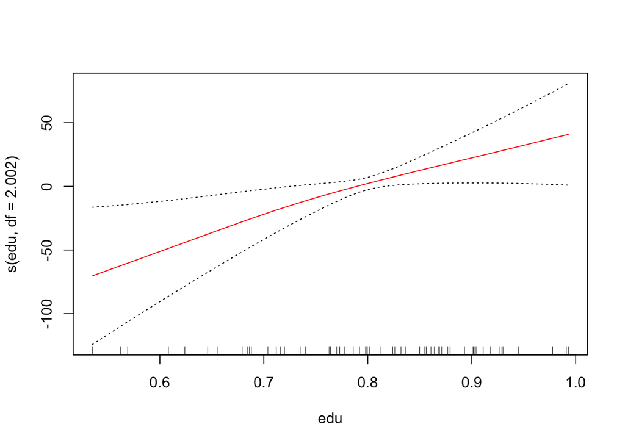

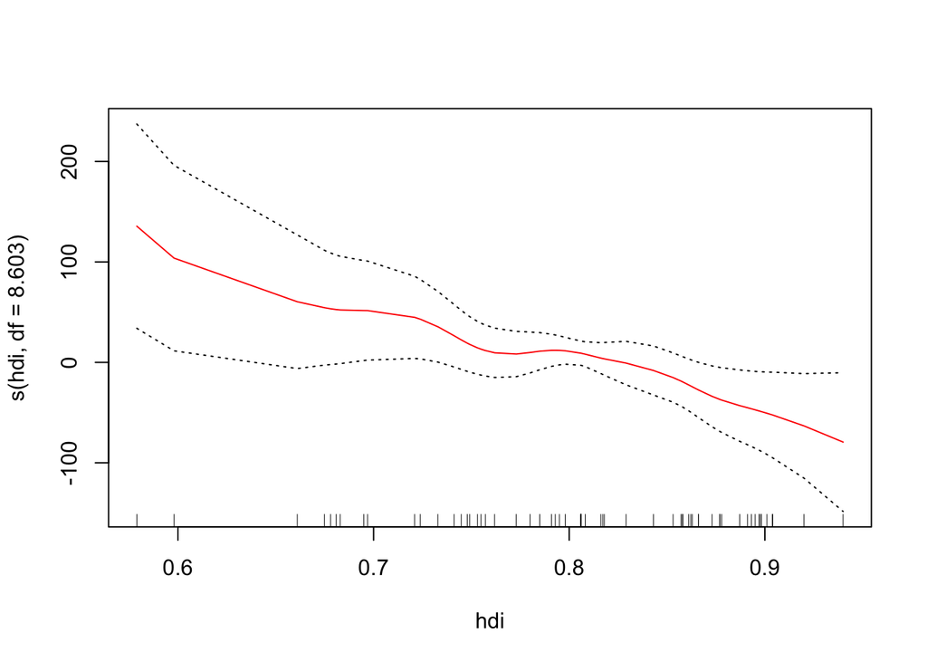

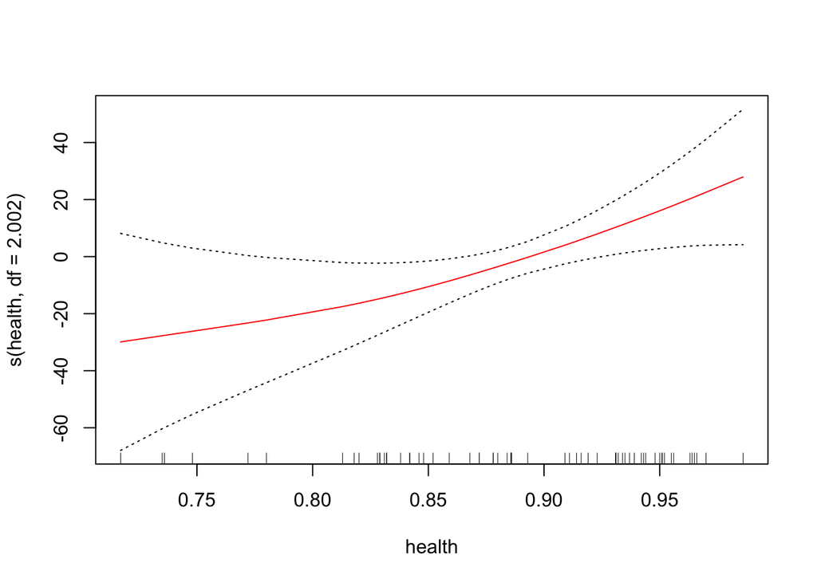

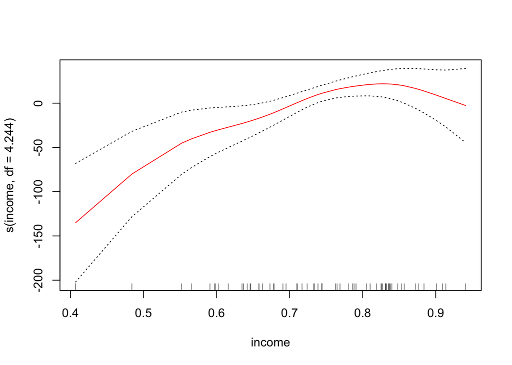

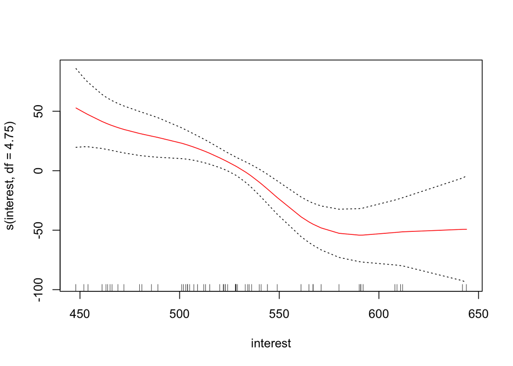

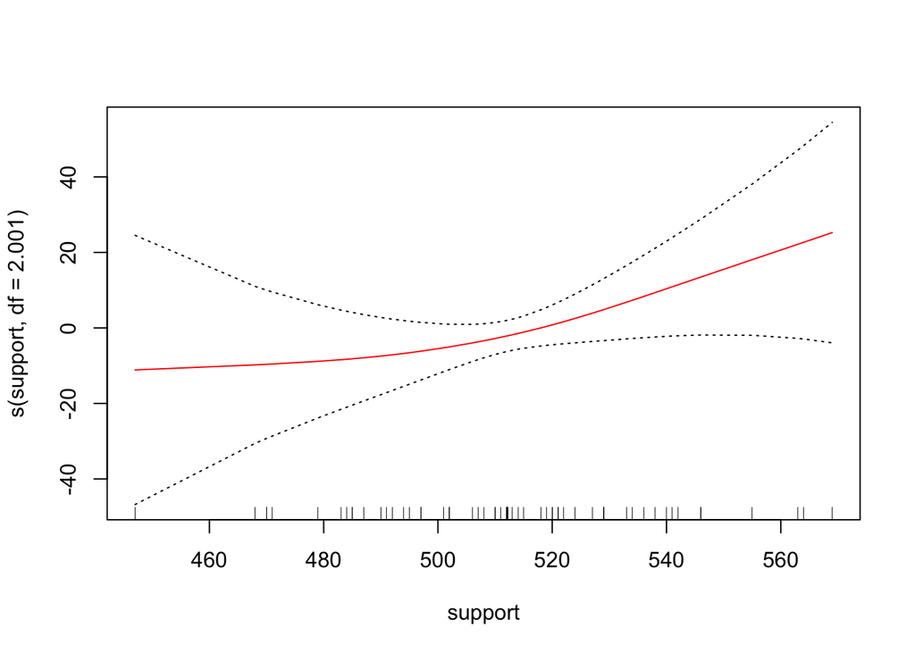

```r
plot(model_gam, se = TRUE, col = "red")
```

Dentro del modelo con la relación no lineal para education, hdi, health y support se puede confirmar que estos componentes no contribuyen al modelo. El p-value obtenido de education, hdi, health y support no demuestra que la relación entre overall y esas variables no sea lineal, por lo que puede darse el caso de que habría sido mejor emplear un ajuste lineal en lugar de una smooth spline, reduciendo la complejidad del modelo. Para ello voy a realizar un análisis ANOVA. Voy a comparar 3 modelos: El primer modelo (modelo_1) que no contiene los predictores , un modelo (modelo_2) que emplea una función lineal para esos predictores y un tercer modelo (model_gam) que emplea smooth spline.

```r
modelo_1 <- gam(overall ~ s(income, df=4.244)+ s(interest, df=4.75), data=pisa)
modelo_2 <- gam(overall ~ support + health + edu + hdi + s(income, df=4.244)+ s(interest, df=4.75), data=pisa)
model_gam <- gam(overall ~ s(edu, df=2.002) + s(hdi, df=8.603) + s(health, df=2.002) +s(income, df=4.244)+ s(interest, df=4.75)+s(support, df=2.001)  , data=pisa)

# método anova para objetos de tipo gam
anova(object = modelo_1, modelo_2, model_gam, test = "F")
```

```
## Analysis of Deviance Table
##
## Model 1: overall ~ s(income, df = 4.244) + s(interest, df = 4.75)
## Model 2: overall ~ support + health + edu + hdi + s(income, df = 4.244) +
##     s(interest, df = 4.75)
## Model 3: overall ~ s(edu, df = 2.002) + s(hdi, df = 8.603) + s(health,
##     df = 2.002) + s(income, df = 4.244) + s(interest, df = 4.75) +
##     s(support, df = 2.001)
##   Resid. Df Resid. Dev     Df Deviance      F Pr(>F)
## 1    55.006      33855
## 2    51.006      29805  4.000   4050.5 1.6985 0.1692
## 3    40.398      24085 10.608   5719.6 0.9044 0.5422
```

Se puede observar que el modelo m_2 es mejor.

```r
summary(modelo_2)
```

```
##
## Call: gam(formula = overall ~ support + health + edu + hdi + s(income,
##     df = 4.244) + s(interest, df = 4.75), data = pisa)
## Deviance Residuals:
##     Min      1Q  Median      3Q     Max
## -61.715 -12.683   3.774  12.768  59.617
##
## (Dispersion Parameter for gaussian family taken to be 584.3422)
##
##     Null Deviance: 166828.9 on 64 degrees of freedom
## Residual Deviance: 29804.93 on 51.006 degrees of freedom
## AIC: 612.7728
##
## Number of Local Scoring Iterations: NA
##
## Anova for Parametric Effects
##                            Df Sum Sq Mean Sq F value    Pr(>F)
## support                 1.000  43580   43580 74.5795 1.493e-11 ***
## health                  1.000  23376   23376 40.0036 6.331e-08 ***
## edu                     1.000   8391    8391 14.3601 0.0004001 ***
## hdi                     1.000   1558    1558  2.6655 0.1087079
## s(income, df = 4.244)   1.000  13863   13863 23.7239 1.119e-05 ***
## s(interest, df = 4.75)  1.000  11570   11570 19.7994 4.687e-05 ***
## Residuals              51.006  29805     584
## ---
## Signif. codes:  0 '***' 0.001 '**' 0.01 '*' 0.05 '.' 0.1 ' ' 1
##
## Anova for Nonparametric Effects
##                        Npar Df Npar F    Pr(F)
## (Intercept)
## support
## health
## edu
## hdi
## s(income, df = 4.244)      3.2 5.8857 0.001212 **
## s(interest, df = 4.75)     3.8 4.0746 0.007082 **
## ---
## Signif. codes:  0 '***' 0.001 '**' 0.01 '*' 0.05 '.' 0.1 ' ' 1
```

A continuación, ajustamos una regresión local en una GAM usando la función lo().

```r
gam.lo <- gam(overall ~ s(edu, df = 2.002)+ s(hdi, df = 8.603) + s(health, df = 2.002)+ s(support, df = 2.001) + lo(income, span=0.7) + lo(interest, span = 0.7),data=pisa)
```

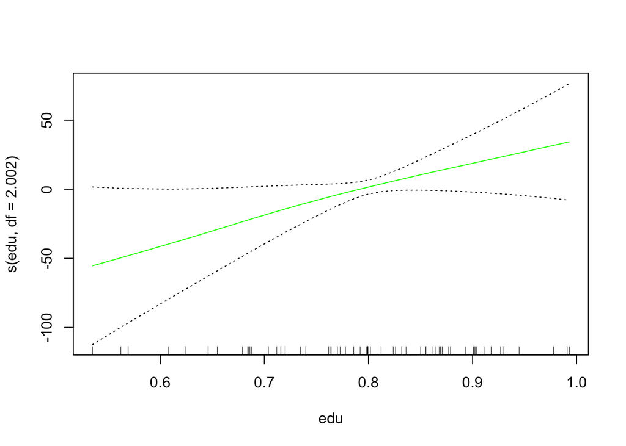

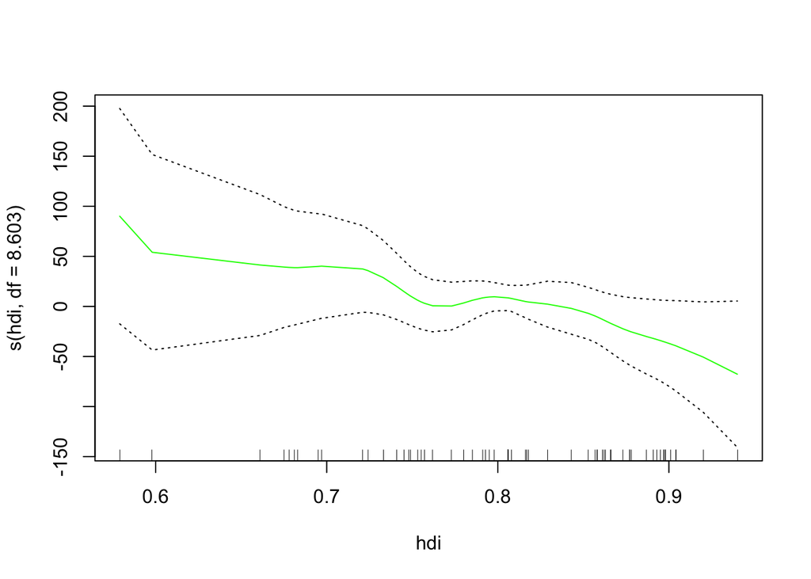

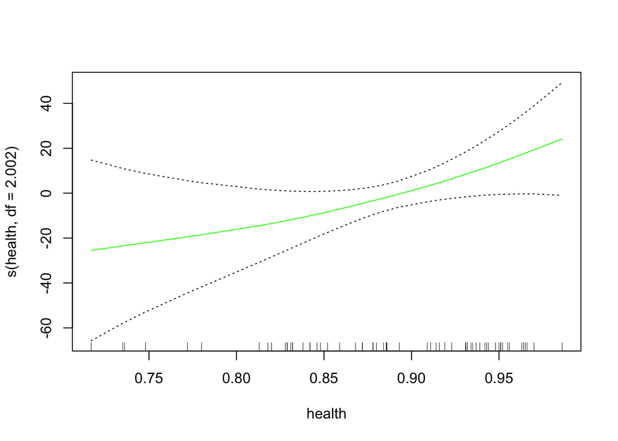

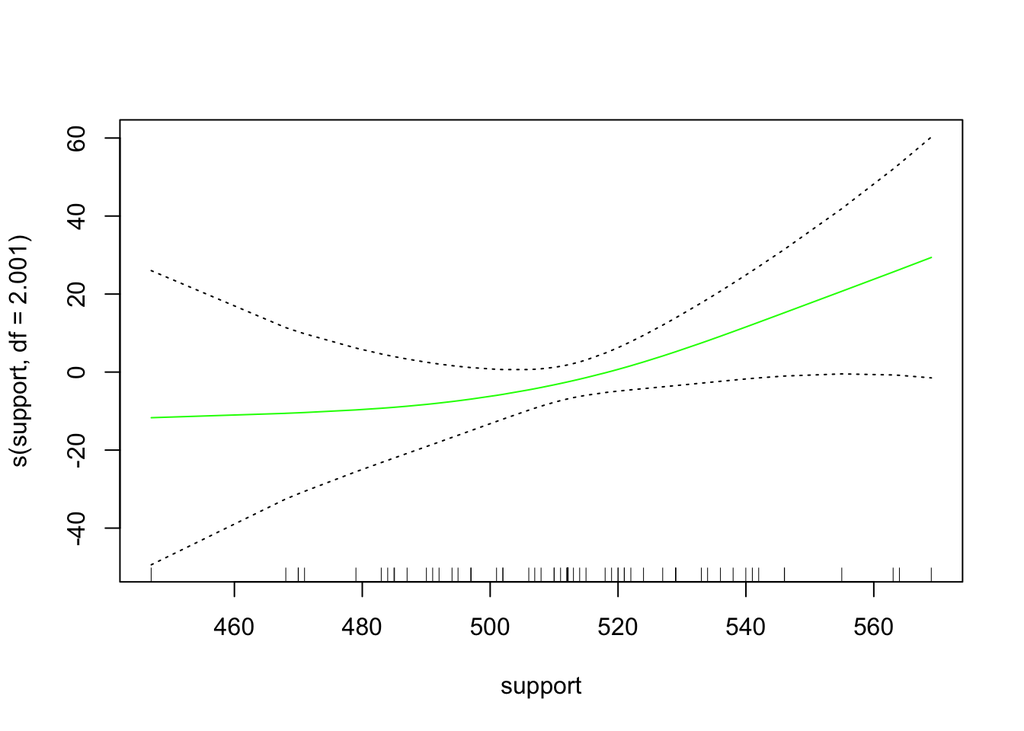

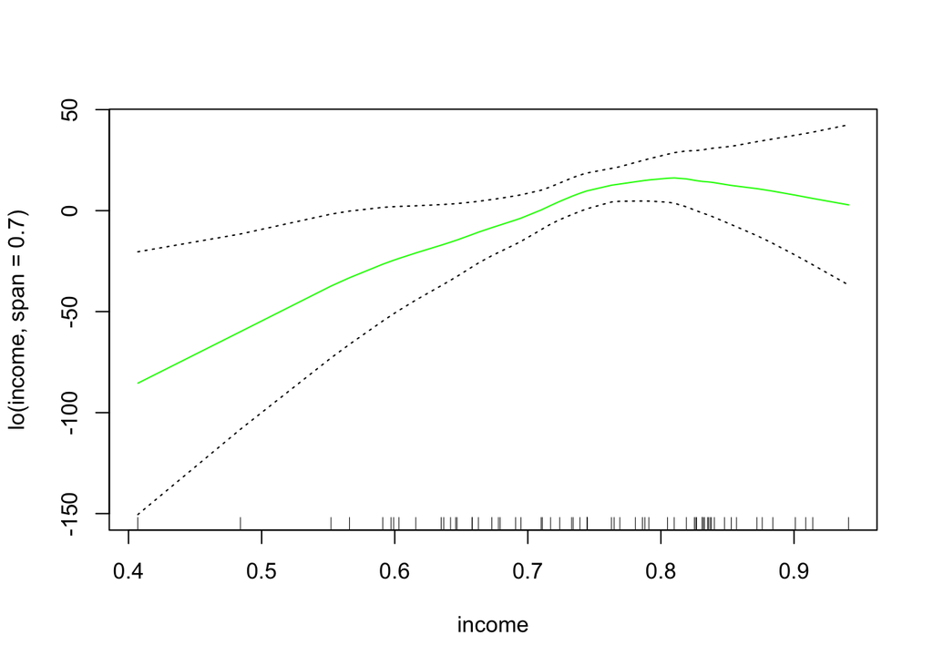

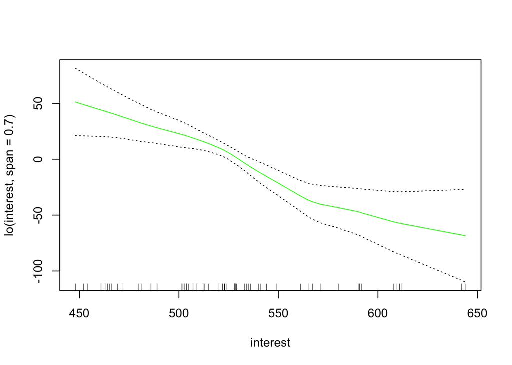

```r
plot(gam.lo, se=TRUE, col='green')
```

Se puede concluir que el mejor modelo es el modelo que emplea una función lineal para support, education, health y hdi, empleando función no lineal para interest e income. De esta forma se ha reducido la complejidad del modelo.